# The Annotated Score Function Estimator

Yao Fu, Columbia University | yao.fu@columbia.edu | Mon Mar 03rd 2020

### A VAE model with categorical latent $z$ for mnist digits

As a baseline, we implement a VAE model for the mnist digits, where the encoder/ inference network $q_\phi(z|x)$ and the decoder $p_\theta(x | x)$ are both MLPs. We use a categorical distribution with 10 class to model $q_\phi(z | x)$. The categorical nature induces non-differentiability, which is tackled by the score function estimator.

### The score function estimator

We denote the gradient of the inference network in the ELBO objective estimated by the score function estimator as:

$$\nabla_\phi [\lambda \cdot \mathbb{E}_{q_\phi(z|x)}[\log p_\theta(x|z)] + \beta \cdot \mathcal{H}(q_\phi(z|x))] = \\ \lambda \cdot \mathbb{E}_{q_\phi(z|x)}[(\log p_\theta(x | z) - b(x)) \nabla_\phi \log q_\phi(z|x)] + \beta \cdot \nabla_\phi\mathcal{H}(q_\phi(z|x)) $$

In our implementation, $\beta$ is denoted as `beta_z`, $\lambda$ is denoted as `lambd_z`

Speciafically, we discuss

- Implementation of the score function estimator
- Training process
- Tuning lambda
- Tuning beta
- lambda and beta are coupled
- Variance of the gradients
- Conclusion

This notebook is, of course, inspired by Sasha Sush's *The Annotated Transformer*: https://nlp.seas.harvard.edu/2018/04/03/attention.html

```python
import argparse
import torch
import torch.utils.data
import numpy as np

from torch import nn
from torch.nn import functional as F
from torch.nn.utils import clip_grad_norm_
from torch.optim import Adam
from torch.distributions import OneHotCategorical

from tensorflow.examples.tutorials.mnist import input_data
```

```python
%matplotlib inline
import matplotlib.pyplot as plt
import matplotlib
matplotlib.rcParams['figure.dpi'] = 200
```

```python
mnist = input_data.read_data_sets('MNIST_data', one_hot=True)
```

# Implementation of the score function estimator

The major part is implemented in the `forward_score_fn` function

The objective `log_p_x`

- This is the ultimate objective that we want to **maximize**
- In our implementation, we use `log_p_x = -F.binary_cross_entropy(x_out, x_target)`.
- Typically in a vanilla VAE, one would use `-log_p_x = F.binary_cross_entropy(x_out, x_target)` and *minimize* it
- We use a negation here because we will need it in the score function estimator

The score function estimator

- is implemented by `loss_z = lambd_z * (log_p_x - b).detach() * log_prob_z`
- We use detach because we only need to differentiate over the log probability of z. Be careful here!
- Note that this formula is specifically for *maximizing* `log_p_x`, and can NOT be used for *minimizing* `-log_p_x` (because then symbol of the baseline would be positive)
- Of course we could instead derive a minimization formula for `-log_p_x`, but here we follow the convension of the literature
- `loss_z` would be the actual loss for the encoder, however, during training, unlike `log_p_x`, it does NOT monotonically increase or decrease, as we will demonstrate

KL divergence between `q(z|x)` and a uniform prior

- is implemented as the *entropy* of of `q(z|x)` as the two are same
- From this perspective, the regularization from a uniform prior can also be viewed as the entropy regularization. It is crutial for a reparameterized estimator.

The final loss `loss = -(log_p_x.mean() + loss_z.mean()) - self.beta_z * ent_z`

- In this equation we negate `log_p_x` and `loss_z` because torch is doing minimization

```python
class CategoricalVAE(nn.Module):
  def __init__(self, num_class, num_sample, beta_z, lambd_z):
    super(CategoricalVAE, self).__init__()

    self.num_sample = num_sample
    self.beta_z = beta_z
    self.lambd_z = lambd_z

    self.fc1 = nn.Linear(784, 400)
    self.fc2 = nn.Linear(400, num_class)
    self.fc3 = nn.Linear(num_class, 400)
    self.fc4 = nn.Linear(400, 784)
    return

  def encode(self, x):
    h1 = F.relu(self.fc1(x))
    logits = self.fc2(h1)
    q_prob = F.softmax(logits, dim=-1)
    log_q_prob = torch.log(q_prob + 1e-10)
    return q_prob, log_q_prob

  def decode(self, z):
    h3 = F.relu(self.fc3(z))
    return torch.sigmoid(self.fc4(h3))

  def sample_hard(self, log_q, num_sample):
    batch_size = log_q.size(0)
    num_class = log_q.size(1)

    log_q = log_q.view(batch_size, 1, num_class).repeat(1, num_sample, 1)
    m = OneHotCategorical(logits=log_q)
    z_sample = m.sample() # [batch, sample, class]
    log_prob_z = m.log_prob(z_sample) # [batch, sample]
    return z_sample, log_prob_z

  def baseline(self, reward):
    num_sample = reward.size(1)
    if(num_sample == 1): return 0
    b = reward.sum(dim=1, keepdim=True)
    b = (b - reward) / (num_sample - 1)
    return b

  def forward_score_fn(self, x):
    batch_size = x.size(0)
    q_prob, log_q_prob = self.encode(x)
    ent_z = -(q_prob * log_q_prob).sum(dim=1).mean()

    z_sample, log_prob_z = self.sample_hard(log_q_prob, self.num_sample)
    x_out = self.decode(z_sample) # [batch, sample, 784]
    x_target = x.view(batch_size, 1, 784).repeat(1, self.num_sample, 1) # [batch, sample, 784]
    log_p_x = -F.binary_cross_entropy(x_out, x_target, reduction='none') # [batch, sample, 784]
    log_p_x = log_p_x.mean(dim=-1) # [batch, sample]

    log_p_x_ = log_p_x.detach()
    b = self.baseline(log_p_x_)
    loss_z = self.lambd_z * (log_p_x_ - b) * log_prob_z

    loss = -(log_p_x.mean() + loss_z.mean()) - self.beta_z * ent_z
    return loss, log_p_x.mean(), loss_z.mean(), ent_z, z_sample
```

# Implementation of the training loops

During training, we inspect the model at every `print_interval = 2000` steps, and visualize the model output for each `z_i` at the end

```python
def visualize(config, model):
  z = np.eye(config['num_class'])
  x = model.decode(torch.from_numpy(z).type(torch.float))
  x = x.view(config['num_class'], 28, 28).detach().numpy()

  if(config['num_class'] > 10):
    img_0 = np.hstack([x[i] for i in range(int(config['num_class'] / 2))])
    img_1 = np.hstack([x[i] for i in range(int(config['num_class'] / 2), config['num_class'])])
    img = np.vstack([img_0, img_1])
  else:
    img = np.hstack([x[i] for i in range(config['num_class'])])
  plt.imshow(img)
  plt.show()
  return

def print_at(i, num_iter, print_interval=2000):
  if(i % print_interval == 0): return True
  elif(i == num_iter - 1): return True
  return False

def report_grad(model):
    """Report the average norm the gradient, used for monitoring training"""
    print('gradient of the model parameters:')

    grad_norms = {}
    grad_std = {}
    for name, param in model.named_parameters():
      frist_level_name = name.split('.')[0]
      if(param.requires_grad and param.grad is not None):
        # print(name, param.grad.norm(), param.grad.std())
        if(frist_level_name in grad_norms):
          grad_norms[frist_level_name].append(
            param.grad.norm().detach().cpu().numpy())
          grad_std[frist_level_name].append(
            param.grad.std().detach().cpu().numpy())
        else:
          grad_norms[frist_level_name] = [
            param.grad.norm().detach().cpu().numpy()]
          grad_std[frist_level_name] = [
            param.grad.std().detach().cpu().numpy()]

    for frist_level_name in grad_norms:
      print(frist_level_name,
        np.average(grad_norms[frist_level_name]),
        np.std(grad_std[frist_level_name]))
    return

def train_score_fn(config, print_log=True):
  model = CategoricalVAE(config['num_class'], config['num_sample'], config['beta_z'], config['lambd_z'])
  params = list(model.parameters())
  opt = Adam(params, 1e-3)

  batch_size = 50

  log_p_x_log = []
  loss_z_log = []
  ent_z_log = []

  if('print_interval' in config): print_interval = config['print_interval']
  else: print_interval = 2000

  for i in range(config['num_iter']):
    x, y = mnist.train.next_batch(batch_size)

    model.zero_grad()
    loss, log_p_x, loss_z, ent_z, z = model.forward_score_fn(torch.from_numpy(x))
    loss.backward()
    opt.step()

    log_p_x = float(log_p_x.detach().cpu().numpy())
    ent_z = float(ent_z.detach().cpu().numpy())
    loss_z = float(loss_z.detach().cpu().numpy())
    log_p_x_log.append(log_p_x)
    loss_z_log.append(loss_z)
    ent_z_log.append(ent_z)

    if(print_at(i, config['num_iter'], print_interval)):
      if(print_log):
        loss = loss.detach().cpu().numpy()
        z = z.detach().numpy()
        print('step %d, log_p_x %.4g, loss_z %.4g, ent_z %.4g' % (i, log_p_x, loss_z, ent_z))
        z_ind = z[:3].argmax(-1)
        print('sampled z index are:', z_ind[0], z_ind[1], z_ind[2])
        report_grad(model)
      else: print('.')

  print('finished!')

  visualize(config, model)
  return model, np.array(log_p_x_log), np.array(loss_z_log), np.array(ent_z_log)
```

# Training process

Below is the standard architecture we will use through this post. we call it **the base model** in our experiments. In the later part we will compare different hyper-parameter settings with this setting

```
step 0, log_p_x -0.6922, loss_z -6.438e-06, ent_z 2.3
sampled z index are: [1 0 0] [5 9 4] [8 0 6]
gradient of the model parameters:
fc1 0.00042859968 2.0243474e-06
fc2 0.00052143534 4.7944297e-05
fc3 0.0037055989 0.00011815574
fc4 0.029803094 7.930955e-05
step 2000, log_p_x -0.2195, loss_z 0.0002912, ent_z 0.1814
sampled z index are: [2 2 2] [6 6 6] [8 8 8]
gradient of the model parameters:
fc1 0.0012592465 2.9329422e-06
fc2 0.005238678 2.4718662e-05
fc3 0.003274044 4.6143105e-05
fc4 0.004315505 1.3990513e-05
step 4000, log_p_x -0.2282, loss_z 0.004071, ent_z 0.2004
sampled z index are: [2 2 2] [0 0 0] [5 5 5]
gradient of the model parameters:
fc1 0.0029434704 6.5740614e-06
fc2 0.008916621 3.432802e-05
fc3 0.005432789 0.00010937238
fc4 0.0042942995 1.863551e-05
step 4999, log_p_x -0.2177, loss_z 0.003929, ent_z 0.2719
sampled z index are: [3 3 3] [0 0 0] [5 5 5]
gradient of the model parameters:
fc1 0.0026001632 6.5986114e-06
fc2 0.0071871923 2.7142865e-05
fc3 0.0033188504 4.354277e-05
fc4 0.003464964 1.50543865e-05
finished!
```

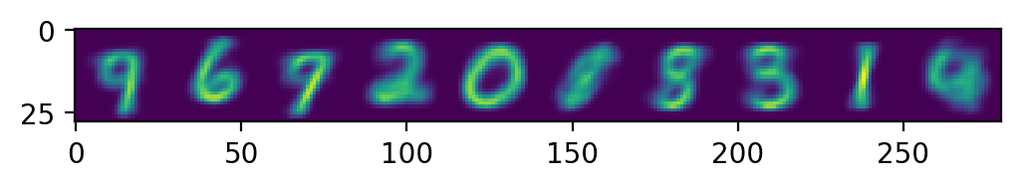

```python
config = {'max_grad_norm': 5.0,
          'num_class': 10,
          'num_sample': 3,
          'beta_z': 0.01,
          'lambd_z': 1.,
          'num_iter': 5000}

model, log_p_x_log, loss_z_log, ent_z_log = train_score_fn(config)
```

During training, we monitor

- `log_p_x`: the optimization objective
- `loss_z`: the auxilary loss of `z`, although we seem to be maximizing it, it is not actually monotonically increasing
- `ent_z`: the entropy of `z`
- gradient of the model parameters, we will further investigate it in the variance reduction section

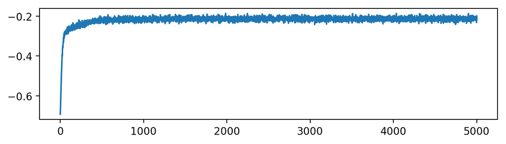

```python
f = plt.figure()
f.set_size_inches(8, 2, forward=True)
plt.plot(log_p_x_log)
```

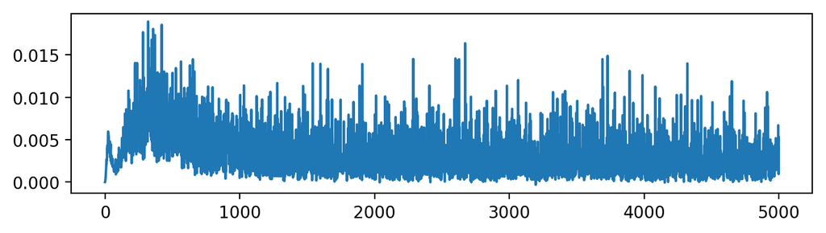

```python
f = plt.figure()
f.set_size_inches(8, 2, forward=True)
plt.plot(loss_z_log)
```

There are two observations:

- The loss of z does not increase or decrease.
- The variance is large

It is interesting to see that `loss_z` does not increase or decrease. In fact, it behaves more like the gradient: either positive or negative, we should have some, and it should not be 0

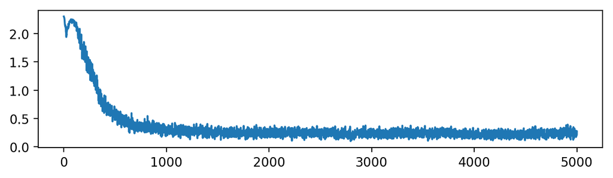

```python
f = plt.figure()
f.set_size_inches(8, 2, forward=True)
plt.plot(ent_z_log)
```

Dispite entropy maximization, we still find a decreasing entropy. But this does not mean that the entropy regularization is not necessary, as we will demonstrate in the following experiments

# Tuning lambd_z

lambd_z controls the scale of the inference network q. Alternatively, we can use seperate optimizers for q and p, and use different learning rate. Since we use the same optimizer here, we use the coefficient `lambd_z`. The goal is to make the norm of the two networks sensible

### Setting a larger `lambd_z`

```
step 0, log_p_x -0.6952, loss_z -0.0002432, ent_z 2.3
sampled z index are: [7 8 8] [8 6 8] [1 6 5]
gradient of the model parameters:
fc1 0.005671719 2.7711601e-05
fc2 0.0065493975 0.00062615785
fc3 0.0036867857 0.00011598637
fc4 0.02836568 8.587154e-05
step 2000, log_p_x -0.2226, loss_z 0.006182, ent_z 0.05755
sampled z index are: [9 6 9] [7 7 7] [6 6 6]
gradient of the model parameters:
fc1 0.0150189465 7.095699e-05
fc2 0.045073483 0.00010936882
fc3 0.0023503725 3.3407032e-05
fc4 0.003962825 1.3468518e-05
step 4000, log_p_x -0.2321, loss_z 0.00341, ent_z 0.06095
sampled z index are: [2 2 2] [6 6 6] [2 2 2]
gradient of the model parameters:
fc1 0.04379064 9.159584e-05
fc2 0.12763877 0.0011316788
fc3 0.0042258287 7.4142015e-05
fc4 0.0037614708 1.5776151e-05
step 4999, log_p_x -0.2216, loss_z 0.007511, ent_z 0.03404
sampled z index are: [7 7 7] [9 9 9] [9 9 9]
gradient of the model parameters:
fc1 0.026016703 7.851009e-05
fc2 0.06341883 0.00043654186
fc3 0.0033232095 5.729422e-05
fc4 0.0035126805 1.6769234e-05
finished!
```

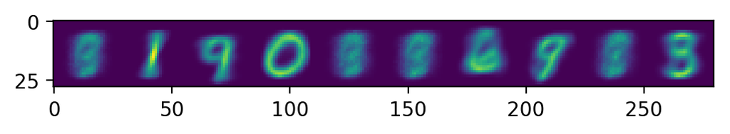

```python
config = {'max_grad_norm': 5.0,
          'num_class': 10,
          'num_sample': 3,
          'beta_z': 0.01,
          'lambd_z': 10,
          'num_iter': 5000}

model, log_p_x_log, loss_z_log, ent_z_log = train_score_fn(config)
```

With a larger `lambd_z` we see a worse convergence, illustrated by the poor generation quality.

Then we inspect `loss_z` and `ent_z`. The behavior will be interesting

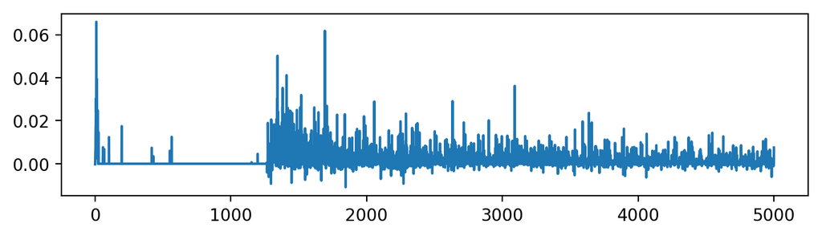

```python
f = plt.figure()
f.set_size_inches(8, 2, forward=True)
plt.plot(loss_z_log)
```

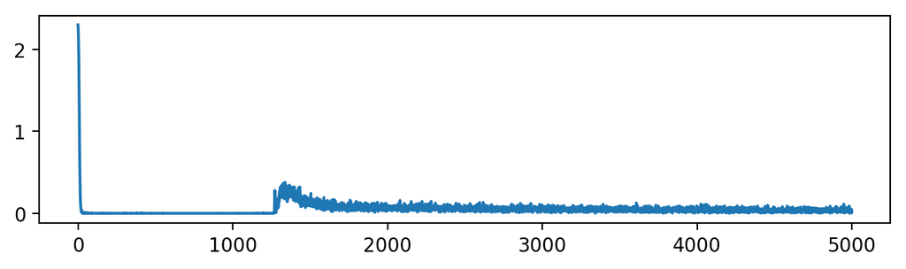

```python
f = plt.figure()
f.set_size_inches(8, 2, forward=True)
plt.plot(ent_z_log)
```

The behavior is interesting as we can see that the model took a while to find out a sensible convergence.

The training curve shows that in the begining of training, due to a larger `lambd_z`, the model did not find a meaningful `loss_z`, and it is close to 0, leading to non-informative gradient. After about 1200 steps, the model gets lucky and start to converge again. But it converges to a worse local as we see a worse sample quality.

Note that runing the above setting with a different random seed may lead to different behaviors.

### Setting a smaller `lambd_z`

would lead to an unsuccessful convergence, as we show below

```
step 0, log_p_x -0.6908, loss_z -5.329e-07, ent_z 2.298
sampled z index are: [3 4 6] [0 4 7] [2 5 2]
gradient of the model parameters:
fc1 0.00032825582 1.8171793e-06
fc2 0.0003740176 4.0619554e-05
fc3 0.003217156 0.00010037171
fc4 0.02911044 7.328711e-05
step 2000, log_p_x -0.2632, loss_z 1.422e-06, ent_z 2.303
sampled z index are: [5 6 7] [9 3 9] [5 5 8]
gradient of the model parameters:
fc1 2.2743839e-06 7.555839e-09
fc2 1.363002e-05 1.7227588e-06
fc3 0.0009339972 9.5796595e-06
fc4 0.0039912094 1.745703e-05
step 4000, log_p_x -0.2493, loss_z 2.943e-07, ent_z 2.303
sampled z index are: [4 3 9] [8 4 5] [6 3 4]
gradient of the model parameters:
fc1 2.0316606e-06 8.490759e-09
fc2 1.1972923e-05 2.292479e-06
fc3 0.0019691156 2.893281e-05
fc4 0.003212756 1.7212426e-05
step 6000, log_p_x -0.2766, loss_z 1.292e-07, ent_z 2.303
sampled z index are: [4 3 1] [6 6 5] [7 6 1]
gradient of the model parameters:
fc1 1.5502259e-06 4.5253583e-09
fc2 1.2002269e-05 1.7670212e-06
fc3 0.0032485933 4.2179807e-05
fc4 0.0027821073 1.8449848e-05
step 8000, log_p_x -0.2686, loss_z 8.059e-07, ent_z 2.303
sampled z index are: [8 9 2] [2 7 9] [1 3 6]
gradient of the model parameters:
fc1 2.8541608e-06 4.175048e-09
fc2 1.3284812e-05 2.7002854e-06
fc3 0.0016655049 2.6971436e-05
fc4 0.0025382766 1.8366914e-05
step 9999, log_p_x -0.2607, loss_z 4.348e-07, ent_z 2.303
sampled z index are: [0 0 4] [6 4 3] [3 0 6]
gradient of the model parameters:
fc1 1.0458551e-06 8.662959e-12
fc2 1.1622326e-05 3.1747456e-06
fc3 0.0014394077 8.987918e-06
fc4 0.0019262348 1.5330628e-05
finished!
```

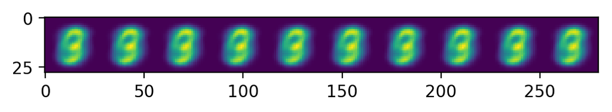

```python
config = {'max_grad_norm': 5.0,
          'num_class': 10,
          'num_sample': 3,
          'beta_z': 0.01,
          'lambd_z': 0.1,
          'anneal_tau': True,
          'num_iter': 10000}

model, log_p_x_log, loss_z_log, ent_z_log = train_score_fn(config)
```

As we can see, setting `lambd_z` to 0.1 leads to:

- a meaningless uniform posterior (regardless of the input), and consequently
- the close-to 2.3 entropy (compared to 0.27+ in the base model)
- the suboptimal reconstruction loss (log_p_x = -0.26, campared to -0.21 in the base model)
- he vanished gradient of the encoder (grad at level of 1e-5, compared to 1e-3 in the base model)
- and the meaningless decoder output

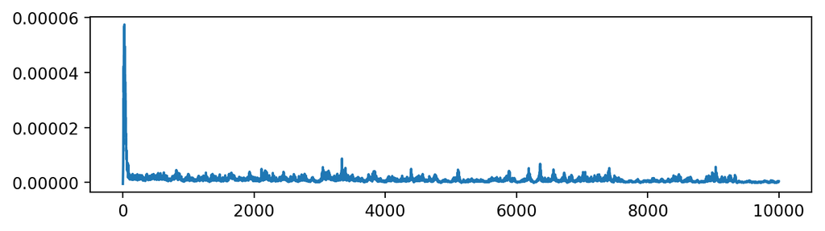

```python
f = plt.figure()
f.set_size_inches(8, 2, forward=True)
plt.plot(loss_z_log)
```

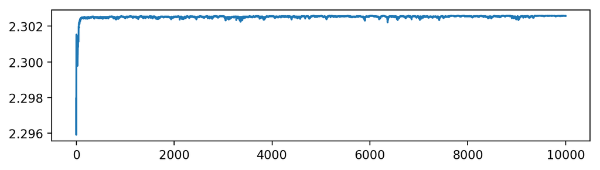

```python
f = plt.figure()
f.set_size_inches(8, 2, forward=True)
plt.plot(ent_z_log)
```

# Tuning beta_z

### Dropping the entropy regularization

Our first question is, can we simply drop the entropy regularization?

```
step 0, log_p_x -0.6946, loss_z -1.781e-05, ent_z 2.3
sample z[0]:
[0. 0. 0. 0. 0. 0. 1. 0. 0. 0.]
[0. 0. 0. 0. 0. 0. 0. 1. 0. 0.]
sample z[1]:
[0. 0. 0. 0. 0. 0. 1. 0. 0. 0.]
[0. 0. 0. 1. 0. 0. 0. 0. 0. 0.]
sampled z index are: [[6 7 5]
 [6 3 4]
 [0 6 3]
 [7 8 4]
 [2 3 6]]
gradient of the model parameters:
fc1 0.00043587683 1.9390418e-06
fc2 0.00046780333 4.1730873e-05
fc3 0.003457338 0.00010824657
fc4 0.027641693 8.494335e-05
step 2000, log_p_x -0.2467, loss_z -7.105e-16, ent_z 8.756e-07
sample z[0]:
[0. 0. 0. 0. 0. 1. 0. 0. 0. 0.]
[0. 0. 0. 0. 0. 1. 0. 0. 0. 0.]
sample z[1]:
[0. 0. 0. 0. 0. 1. 0. 0. 0. 0.]
[0. 0. 0. 0. 0. 1. 0. 0. 0. 0.]
sampled z index are: [[5 5 5]
 [5 5 5]
 [5 5 5]
 [5 5 5]
 [5 5 5]]
gradient of the model parameters:
fc1 1.689046e-15 1.0136749e-17
fc2 6.533856e-15 3.2567583e-17
fc3 0.0028080326 2.705296e-05
fc4 0.004147631 1.45236945e-05
step 4000, log_p_x -0.271, loss_z -7.105e-17, ent_z 1.379e-07
sample z[0]:
[0. 0. 0. 0. 0. 1. 0. 0. 0. 0.]
[0. 0. 0. 0. 0. 1. 0. 0. 0. 0.]
sample z[1]:
[0. 0. 0. 0. 0. 1. 0. 0. 0. 0.]
[0. 0. 0. 0. 0. 1. 0. 0. 0. 0.]
sampled z index are: [[5 5 5]
 [5 5 5]
 [5 5 5]
 [5 5 5]
 [5 5 5]]
gradient of the model parameters:
fc1 2.7934869e-16 1.0057165e-18
fc2 8.5021594e-16 2.0476128e-18
fc3 0.0027702213 2.7385166e-05
fc4 0.004125344 1.9223271e-05
finished!
```

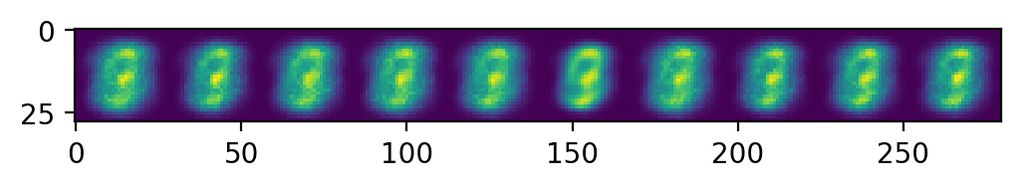

```python
config = {'max_grad_norm': 5.0,
          'num_class': 10,
          'num_sample': 3,
          'beta_z': 0.00,
          'lambd_z': 1.,
          'anneal_tau': True}

model, log_p_x_log, loss_z_log, ent_z_log = train_score_fn(config)
```

### Setting a larger regularization strength

Then our next question is, can the regularization strength be too large?

```
step 0, log_p_x -0.6952, loss_z -6.689e-07, ent_z 2.3
sample z[0]:
[1. 0. 0. 0. 0. 0. 0. 0. 0. 0.]
[0. 0. 1. 0. 0. 0. 0. 0. 0. 0.]
sample z[1]:
[0. 0. 0. 0. 0. 1. 0. 0. 0. 0.]
[0. 0. 0. 0. 0. 0. 1. 0. 0. 0.]
sampled z index are: [[0 2 0]
 [5 6 2]
 [7 3 5]
 [0 7 9]
 [4 4 1]]
gradient of the model parameters:
fc1 0.0024628385 1.3401839e-05
fc2 0.0029688436 0.00028993658
fc3 0.0033277967 0.000103262566
fc4 0.028999463 7.659219e-05
step 2000, log_p_x -0.2741, loss_z 2.175e-05, ent_z 2.302
sample z[0]:
[0. 0. 0. 0. 0. 0. 0. 0. 0. 1.]
[0. 0. 0. 1. 0. 0. 0. 0. 0. 0.]
sample z[1]:
[1. 0. 0. 0. 0. 0. 0. 0. 0. 0.]
[0. 0. 0. 0. 1. 0. 0. 0. 0. 0.]
sampled z index are: [[9 3 8]
 [0 4 5]
 [4 2 7]
 [3 8 7]
 [9 9 7]]
gradient of the model parameters:
fc1 2.1120766e-05 4.4718554e-08
fc2 0.0003227873 3.429497e-05
fc3 0.0017842083 2.561883e-05
fc4 0.0048030866 2.0263347e-05
step 4000, log_p_x -0.2644, loss_z 2.796e-06, ent_z 2.303
sample z[0]:
[0. 1. 0. 0. 0. 0. 0. 0. 0. 0.]
[0. 0. 0. 0. 0. 0. 0. 0. 1. 0.]
sample z[1]:
[0. 0. 0. 0. 0. 0. 0. 0. 0. 1.]
[0. 0. 0. 0. 0. 0. 1. 0. 0. 0.]
sampled z index are: [[1 8 3]
 [9 6 9]
 [6 7 9]
 [8 5 8]
 [2 6 4]]
gradient of the model parameters:
fc1 7.4525474e-06 6.5904615e-10
fc2 6.440103e-05 1.2558046e-05
fc3 0.0012753054 1.34824595e-05
fc4 0.0032006828 1.786672e-05
finished!
```

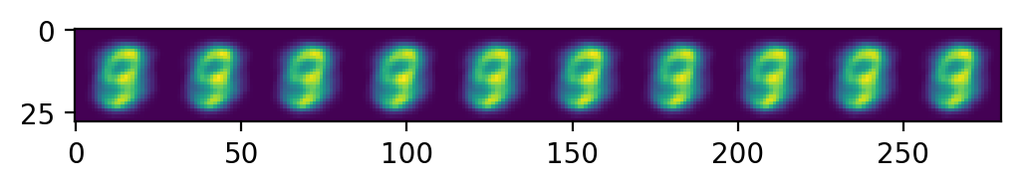

```python
config = {'max_grad_norm': 5.0,
          'num_class': 10,
          'num_sample': 3,
          'beta_z': 0.1,
          'lambd_z': 1.,
          'anneal_tau': True}

model, log_p_x_log, loss_z_log, ent_z_log = train_score_fn(config)
```

The answer is still no. As we can see, setting `beta_z` to 0.1 would lead to

- a meaningless uniform posterior (a uniform distribution with 10 class has entropy 2.3)
- the vanished gradient of the encoder (grad at level of 1e-5, compared to 1e-3 in the base model)
- the suboptimal reconstruction loss (log_p_x = -0.26, campared to -0.21 when in the base model)
- and the meaningless decoder output

# lambda and beta are coupled

This indicates that the scale of `beta_z` and `lambd_z` should be paired. Specifically we show that holding other parameters fixed, the following `(beta_z, lambd_z)` pairs are effective:

- (0.1, 10)
- (0.01, 1.0) - our base model
- (0.001, 0.1)

Below we show the experiments on `(beta_z = 0.1, lambd_z = 10)`

```
step 0, log_p_x -0.6949, loss_z -0.0003903, ent_z 2.3
sampled z index are: [5 8 2] [5 2 0] [5 6 4]
gradient of the model parameters:
fc1 0.00643858 3.5627123e-05
fc2 0.007753703 0.0008431511
fc3 0.0036919157 0.00011474164
fc4 0.027453702 8.203148e-05
step 2000, log_p_x -0.2213, loss_z 0.07524, ent_z 0.3573
sampled z index are: [1 1 1] [7 7 2] [5 2 2]
gradient of the model parameters:
fc1 0.042482205 0.00021287083
fc2 0.12371186 0.00046351878
fc3 0.0033447905 4.6349338e-05
fc4 0.0038612955 1.3284083e-05
step 4000, log_p_x -0.2261, loss_z 0.04756, ent_z 0.2486
sampled z index are: [2 9 2] [6 6 6] [1 1 1]
gradient of the model parameters:
fc1 0.025716102 9.711599e-05
fc2 0.07793835 4.886929e-05
fc3 0.004372361 5.9097983e-05
fc4 0.0038494086 1.6169479e-05
step 4999, log_p_x -0.2022, loss_z 0.01137, ent_z 0.2232
sampled z index are: [3 3 4] [9 9 9] [6 6 6]
gradient of the model parameters:
fc1 0.01222618 4.389017e-05
fc2 0.048648253 7.652328e-06
fc3 0.0031570033 4.467038e-05
fc4 0.0032363972 1.5079197e-05
finished!
```

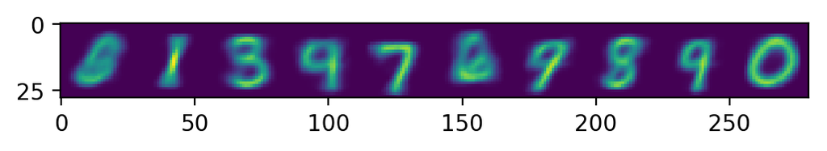

```python
config = {'max_grad_norm': 5.0,
          'num_class': 10,
          'num_sample': 3,
          'beta_z': 0.1,
          'lambd_z': 10,
          'anneal_tau': True,
          'num_iter': 5000}

model, log_p_x_log, loss_z_log, ent_z_log = train_score_fn(config)
```

We can see the model converges well.

Note that as a consequence, the encoder gradient scale rise to 1e-2

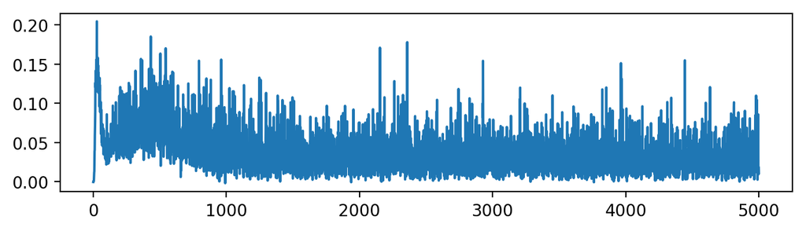

```python
f = plt.figure()
f.set_size_inches(8, 2, forward=True)
plt.plot(loss_z_log)
```

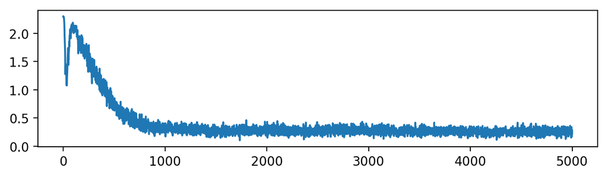

```python
f = plt.figure()
f.set_size_inches(8, 2, forward=True)
plt.plot(ent_z_log)
```

The training curves are also sensible.

Then we show the experiments on `(beta_z = 0.001, lambd_z = 0.1)`

```
step 0, log_p_x -0.6983, loss_z -9.9e-07, ent_z 2.297
sampled z index are: [5 6 1] [7 7 5] [1 1 9]
gradient of the model parameters:
fc1 5.5869365e-05 2.5889057e-07
fc2 7.0479815e-05 6.5643276e-06
fc3 0.0034337637 0.00010629924
fc4 0.027142672 8.478923e-05
step 2000, log_p_x -0.1973, loss_z 0.0006171, ent_z 0.202
sampled z index are: [0 0 0] [9 9 9] [9 9 9]
gradient of the model parameters:
fc1 0.00038466428 1.0809879e-06
fc2 0.0014458819 5.214566e-06
fc3 0.0025040032 3.3736615e-05
fc4 0.0035550385 1.2035617e-05
step 4000, log_p_x -0.2204, loss_z 0.0006501, ent_z 0.2247
sampled z index are: [6 6 6] [2 2 2] [6 6 6]
gradient of the model parameters:
fc1 0.00034828004 1.4927912e-06
fc2 0.0010053202 1.5022688e-06
fc3 0.003890438 5.6582157e-05
fc4 0.0035208962 1.5188754e-05
step 4999, log_p_x -0.2075, loss_z 0.000483, ent_z 0.2402
sampled z index are: [3 3 3] [5 5 5] [8 8 8]
gradient of the model parameters:
fc1 0.00026108173 5.909453e-07
fc2 0.0008470582 8.455663e-08
fc3 0.003270885 4.8397393e-05
fc4 0.0030100294 1.3764356e-05
finished!
```

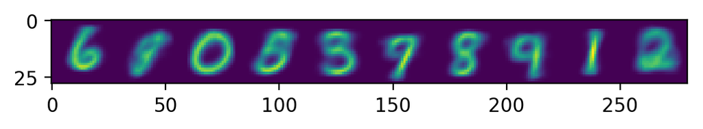

```python
config = {'max_grad_norm': 5.0,
          'num_class': 10,
          'num_sample': 3,
          'beta_z': 0.001,
          'lambd_z': 0.1,
          'anneal_tau': True,
          'num_iter': 5000}

model, log_p_x_log, loss_z_log, ent_z_log = train_score_fn(config)
```

We can see the model still converges well.

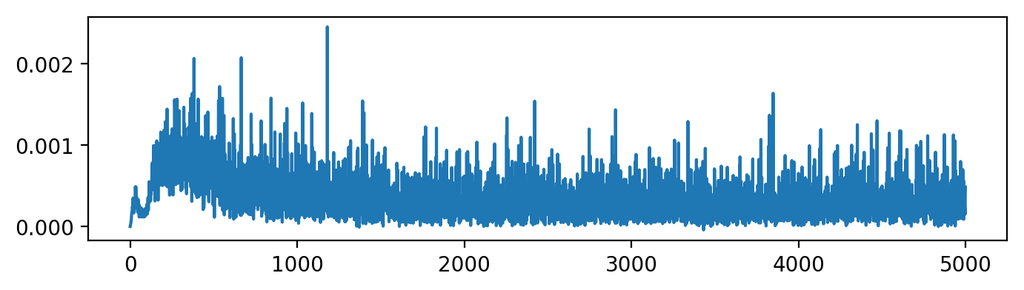

```python
f = plt.figure()
f.set_size_inches(8, 2, forward=True)
plt.plot(loss_z_log)
```

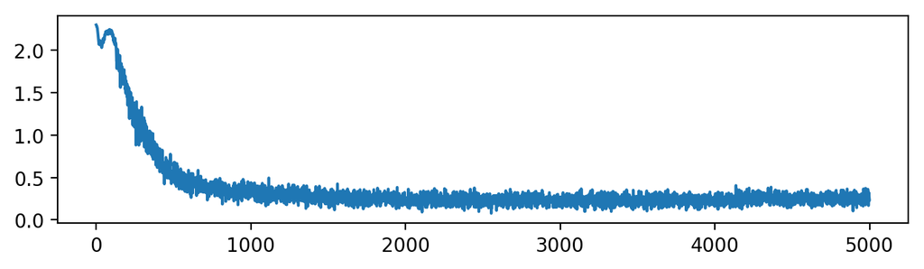

```python
f = plt.figure()
f.set_size_inches(8, 2, forward=True)
plt.plot(ent_z_log)
```

and the training curve is sensible.

Now we discuss the

# Variance of the gradients

First, we run the base model again

```
step 0, log_p_x -0.6956, loss_z 2.319e-06, ent_z 2.3
sampled z index are: [8 7 8] [7 6 7] [3 5 2]
gradient of the model parameters:
fc1 0.000472128 2.3924863e-06
fc2 0.0005517311 5.2541945e-05
fc3 0.0034375445 0.000104350984
fc4 0.026161348 8.895188e-05
step 2000, log_p_x -0.2175, loss_z 0.003033, ent_z 0.219
sampled z index are: [9 4 4] [8 8 8] [7 7 7]
gradient of the model parameters:
fc1 0.0023156563 8.001682e-06
fc2 0.009103973 1.8591585e-05
fc3 0.0033941064 4.1987343e-05
fc4 0.004001925 1.5023037e-05
step 4000, log_p_x -0.2158, loss_z 0.003441, ent_z 0.1965
sampled z index are: [4 4 4] [8 8 8] [9 4 9]
gradient of the model parameters:
fc1 0.0019316274 8.590614e-06
fc2 0.0057214308 6.5960558e-06
fc3 0.0034499923 4.4748056e-05
fc4 0.003161271 1.30999515e-05
step 4999, log_p_x -0.2215, loss_z 0.001372, ent_z 0.2465
sampled z index are: [6 6 6] [7 7 7] [0 0 0]
gradient of the model parameters:
fc1 0.0014374601 4.803383e-06
fc2 0.0054681776 6.596929e-06
fc3 0.004232946 6.779427e-05
fc4 0.003956192 1.9966777e-05
finished!
```

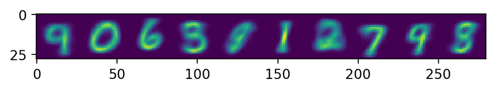

```python
config = {'max_grad_norm': 5.0,
          'num_class': 10,
          'num_sample': 3,
          'beta_z': 0.01,
          'lambd_z': 1,
          'anneal_tau': True,
          'num_iter': 5000,
          'print_interval': 2000}

model_0, log_p_x_log_0, loss_z_log_0, ent_z_log_0 = train_score_fn(config)
```

### The increased variance without baseline, and the generation quality

```
step 0, log_p_x -0.6955, loss_z 1.599, ent_z 2.301
sampled z index are: [8] [2] [7]
gradient of the model parameters:
fc1 0.18123856 0.0005066351
fc2 0.14037195 0.010043774
fc3 0.0039141295 0.00012011604
fc4 0.02869168 8.202075e-05
step 2000, log_p_x -0.2307, loss_z 0.1525, ent_z 0.6066
sampled z index are: [0] [3] [4]
gradient of the model parameters:
fc1 0.05737723 0.00013592427
fc2 0.14807442 0.00013435609
fc3 0.0029059178 5.2785566e-05
fc4 0.0047892365 1.8250272e-05
step 4000, log_p_x -0.2195, loss_z 0.07638, ent_z 0.4248
sampled z index are: [3] [3] [6]
gradient of the model parameters:
fc1 0.03569876 9.1567206e-05
fc2 0.08333283 9.577256e-05
fc3 0.0026365882 3.9595576e-05
fc4 0.0036122324 1.4891694e-05
step 4999, log_p_x -0.2259, loss_z 0.14, ent_z 0.5226
sampled z index are: [2] [9] [9]
gradient of the model parameters:
fc1 0.10810219 0.00023619985
fc2 0.43606955 0.0019811187
fc3 0.003340702 5.763104e-05
fc4 0.0038580233 1.9059344e-05
finished!
```

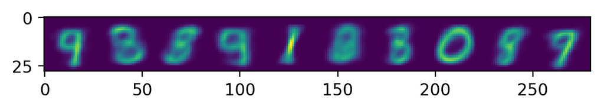

```python
config = {'max_grad_norm': 5.0,
          'num_class': 10,
          'num_sample': 1,
          'beta_z': 0.01,
          'lambd_z': 1,
          'num_iter': 5000,
          'print_interval': 2000}

model_nv, log_p_x_log_nv, loss_z_log_nv, ent_z_log_nv = train_score_fn(config)
```

Here we compare the generation quality between models with/ without variance reduction

```python
def compare_model_outputs(model_0, model_1, config):
  z = np.eye(config['num_class'])
  x_0 = model_0.decode(torch.from_numpy(z).type(torch.float))
  x_0 = x_0.view(config['num_class'], 28, 28).detach().numpy()

  z = np.eye(config['num_class'])
  x_1 = model_1.decode(torch.from_numpy(z).type(torch.float))
  x_1 = x_1.view(config['num_class'], 28, 28).detach().numpy()

  img_0 = np.hstack([x_0[i] for i in range(int(config['num_class']))])
#   img_1 = np.hstack([x_0[i] for i in range(int(config['num_class'] / 2), config['num_class'])])
  img_x = np.zeros_like(img_0)
  img_2 = np.hstack([x_1[i] for i in range(int(config['num_class']))])
#   img_3 = np.hstack([x_1[i] for i in range(int(config['num_class'] / 2), config['num_class'])])

  img = np.vstack([img_0, img_x, img_2])
  plt.imshow(img)
  plt.show()
  return
```

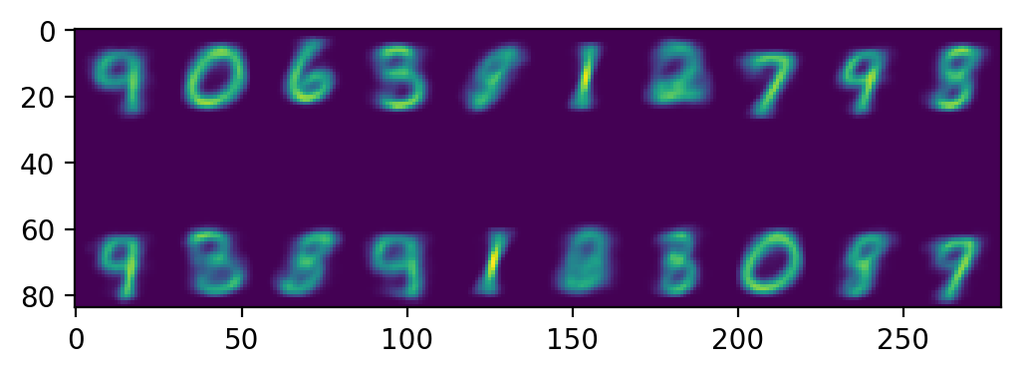

```python
compare_model_outputs(model_0, model_nv, config)
```

Upper: with variance reductionm. Lower: without variance reduction.

Clearly we see a worse generation quality without variance reduction. Now we visualize the variance in the training curve

```python
def compare_training_curve(curve_0, curve_1):
  f, (ax1, ax2) = plt.subplots(1, 2, sharey=True)
  f.set_size_inches(8, 2, forward=True)
  x = np.arange(len(curve_0))
  ax1.plot(x, curve_0)
  ax2.plot(x, curve_1)
  plt.show()
  return
```

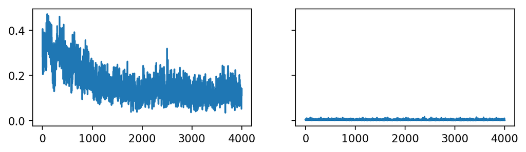

```python
compare_training_curve(loss_z_log_nv[1000:], loss_z_log_0[1000:])
```

Left: no variance reduction; right: variance reduction with 3 samples. It is clear that the right figure has less variance

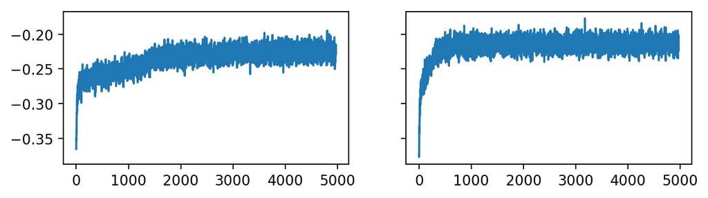

```python
compare_training_curve(log_p_x_log_nv[30:5000], log_p_x_log_0[30:5000])
```

Left: no variance reduction; right: variance reduction with 3 samples

We see a better log likelihood curve

### Variance reduction with more sample

```
step 0, log_p_x -0.6946, loss_z -2.358e-05, ent_z 2.3
sampled z index are: [6 2 1 9 2 3 8 3 7 9] [2 9 3 6 7 3 6 4 4 4] [9 1 9 8 9 5 9 0 1 3]
gradient of the model parameters:
fc1 0.00045708992 2.577755e-06
fc2 0.00057215523 5.8409838e-05
fc3 0.003565051 0.000114080314
fc4 0.028382113 7.397041e-05
step 2000, log_p_x -0.2188, loss_z 0.003699, ent_z 0.268
sampled z index are: [0 0 0 0 0 0 0 0 0 0] [7 7 7 7 7 7 7 7 7 7] [3 7 7 0 0 0 7 7 9 0]
gradient of the model parameters:
fc1 0.0014687239 4.701098e-06
fc2 0.005614031 1.1941265e-05
fc3 0.0038910161 7.738923e-05
fc4 0.004449904 1.6569758e-05
step 4000, log_p_x -0.206, loss_z 0.002213, ent_z 0.229
sampled z index are: [8 8 8 8 8 8 8 8 8 8] [2 2 2 2 2 2 5 2 2 2] [4 4 9 4 4 4 4 4 4 9]
gradient of the model parameters:
fc1 0.0011880157 3.4217296e-06
fc2 0.0036995541 1.716088e-05
fc3 0.004108666 7.531111e-05
fc4 0.0037700143 1.597083e-05
step 4999, log_p_x -0.2095, loss_z 0.002, ent_z 0.2227
sampled z index are: [1 1 1 1 1 9 9 9 1 1] [6 6 6 6 6 6 6 7 6 7] [4 4 4 4 4 4 4 4 4 4]
gradient of the model parameters:
fc1 0.00068194134 2.2365527e-06
fc2 0.0024789313 4.8317415e-06
fc3 0.0054153074 9.3792834e-05
fc4 0.00379469 1.8001567e-05
finished!
```

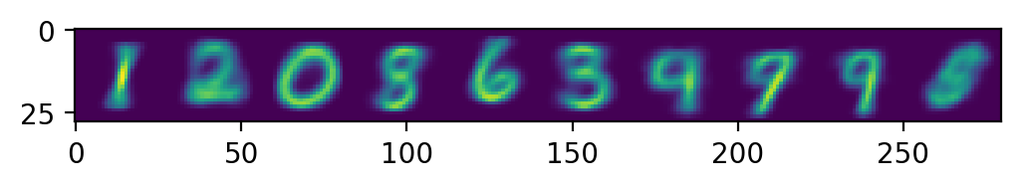

```python
config = {'max_grad_norm': 5.0,
          'num_class': 10,
          'num_sample': 10,
          'beta_z': 0.01,
          'lambd_z': 1,
          'anneal_tau': True,
          'num_iter': 5000,
          'print_interval': 2000}

model, log_p_x_log, loss_z_log, ent_z_log = train_score_fn(config)
```

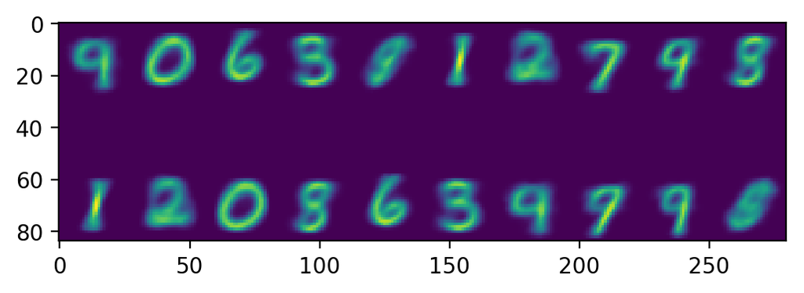

```python
compare_model_outputs(model_0, model, config)
```

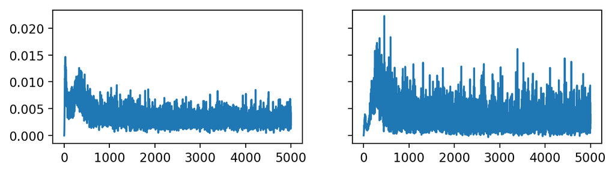

```python
compare_training_curve(loss_z_log, loss_z_log_0)
```

Left: variance reduction with 10 samples; right: variance reduction with 3 samples

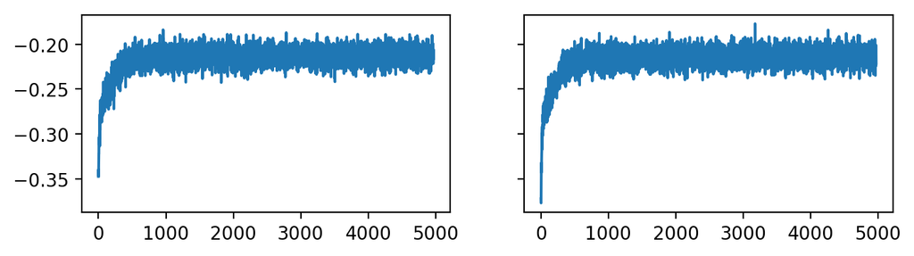

```python
compare_training_curve(log_p_x_log[30:5000], log_p_x_log_0[30:5000])
```

We see approximately the same log likelihood curve

# Conclusion

In this post, we discuss the engineering details of the score function estimator.

- We first give an implementation of the estimator, highlighting the **symbols** of the loss terms, and that we need to **detach the reward** for unbiasedness.
- Then we show that the two parameters `lambd_z` and `beta_z` are coupled. One should tune them carefully to find the right pair.
- Finally we visualize the nessecity of variance reduction and show how it improves training.